# Streets and Networks

Chris Dsida

10/6/2020

```r
# Loading Packages

library(osmdata)
library(opentripplanner)
library(tidyverse)
library(sf)
library(ggthemes)
library(ggspatial)
```

In this assignment, I will be exploring accessibility of polling places in Somerville by different modes.

```r
# Loading data and crs

MA_state_plane <- "+proj=lcc +lat_1=41.71666666666667 +lat_2=42.68333333333333 +lat_0=41 +lon_0=-71.5 +x_0=200000 +y_0=750000 +ellps=GRS80 +units=m +no_defs"

som_polling <- st_read("C:/Users/chris/Documents/Github/chrisdsida-vis/Assignment-4-data/PollingPlaces/PollingPlaces.shp", quiet = TRUE) %>%
  st_transform(crs = '+proj=longlat')

som_border <- st_read("C:/Users/chris/Documents/Github/chrisdsida-vis/Assignment-3-data/CityLimits/CityLimits.shp", quiet = TRUE) %>%
  st_transform(crs = MA_state_plane)
```

Below is the one-time code to set up OpenStreetMap. I left it in my code (but commented out) for no particular reason.

```r
# opq(bbox = 'Somerville MA USA') %>%
#  add_osm_feature(key = 'highway') %>%
#  osmdata_xml(file = 'OTP/graphs/default/somerville_streets.osm')
```

Like the tutorial, I wanted to make sure that OSM was functioning, so I wanted to plot Somerville’s streets.

```r
# Testing OSM with streets

som_street_features <- opq(bbox = 'Somerville MA USA') %>%
  add_osm_feature(key = 'highway') %>%
  osmdata_sf()

som_streets <- som_street_features$osm_lines %>%
  st_transform(crs = MA_state_plane)
```

Yay! It works.

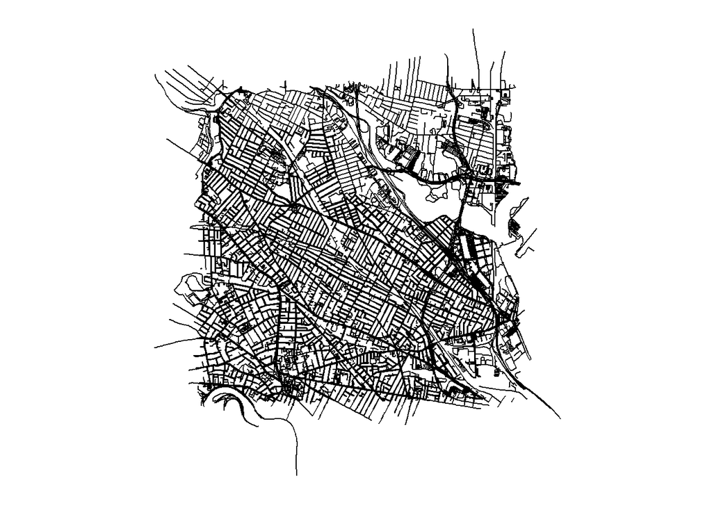

```r
# Plotting streets

ggplot(som_streets) +
  geom_sf() +
  theme_map()
```

Another remnant of the original time I ran the code, commented out. Maybe I just want to have a record that I did it at some point?

```r
# path_otp <- otp_dl_jar("OTP")
```

Next, following along with the tutorial, I am going to build a graph…

```r
# Building graph

path_data <- file.path(getwd(), "OTP")
path_otp <- paste(path_data, "otp.jar",sep = "/")

otp_build_graph(otp = path_otp, dir = path_data, memory = 1024)
```

… and launch OTP:

```r
# Launch OTP

otp_setup(otp = path_otp, dir = path_data, memory =1024)

otpcon <- otp_connect()
```

With OTP running, I want to make isochrones around the polling places for a five minute walk and bike, respectively.

```r
# Generate isochrones

iso_5min_walk <-
  otp_isochrone(otpcon = otpcon, fromPlace = som_polling,
                mode = "WALK", cutoffSec = 300) %>%
  st_transform(crs = MA_state_plane) %>%
  mutate(mode = "walk")

iso_5min_bike <-
  otp_isochrone(otpcon = otpcon, fromPlace = som_polling,
                mode = "BICYCLE", cutoffSec = 300) %>%
  st_transform(crs = MA_state_plane) %>%
  mutate(mode = "bike")

iso_all_modes <- rbind(iso_5min_bike, iso_5min_walk)

otp_stop(warn = FALSE)
```

Then, we can map these isochrones:

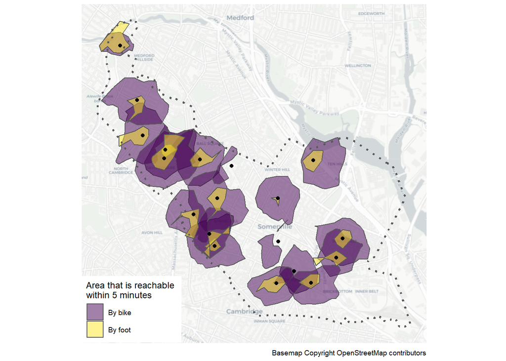

```r
# Mapping isochrones

right_side <- st_bbox(iso_all_modes)$xmax
left_side  <- st_bbox(iso_all_modes)$xmin
top_side <- st_bbox(iso_all_modes)$ymax
bottom_side <- st_bbox(iso_all_modes)$ymin

ggplot(iso_all_modes) +
  annotation_map_tile(zoomin = 0, type = "cartolight", progress = "none") +
  geom_sf(aes(fill = mode), alpha = 0.5) +
  geom_sf(data = som_polling) +
  coord_sf(xlim = c(left_side, right_side),
           ylim = c(bottom_side, top_side), expand = FALSE) +
  scale_fill_viridis_d(name = "Area that is reachable \nwithin 5 minutes",
                       labels = c("By bike", "By foot", "By transit")) +
  geom_sf(data = som_border, fill = NA, linetype = "dotted", size = 1) +
  theme_map() +
  labs(caption = "Basemap Copyright OpenStreetMap contributors")
```

We can compare the areas covered by the walksheds and bikesheds, using the same technique from the tutorial. One thing to note is that two of the polling places did not generate walksheds (and therefore are not included on the chart). My guess is that the coordinates are not located on a part of the OTP network that is categorized as appropriate for walking.

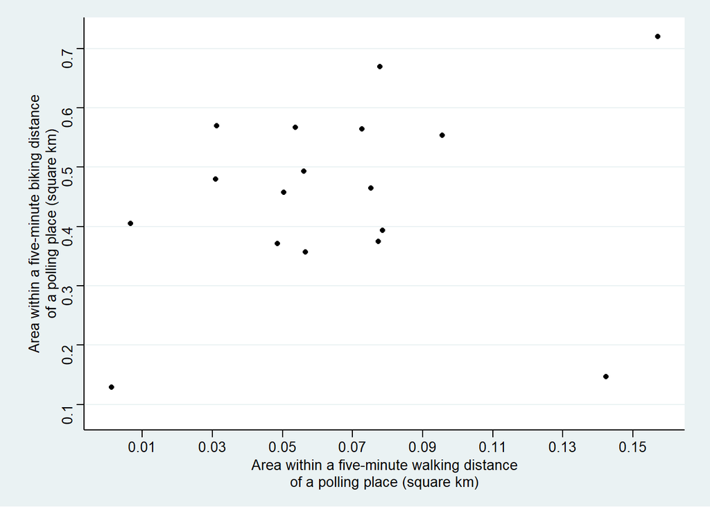

```r
# Area comparison chart

iso_areas <- iso_all_modes %>%
  mutate(area = st_area(iso_all_modes)) %>%
  st_set_geometry(NULL) %>%
  pivot_wider(names_from = mode, values_from = area)

ggplot(iso_areas,
       aes(x = as.numeric(walk), y = as.numeric(bike))) +
  geom_point() +
  scale_x_continuous(name =
            "Area within a five-minute walking distance\nof a polling place (square km)",
            breaks = breaks <- seq(10000, 160000, by = 20000),
            labels = breaks / 1000000) +
  scale_y_continuous(name =
            "Area within a five-minute biking distance\nof a polling place (square km)",
            breaks = breaks <- seq(0, 1000000, by = 100000),
            labels = breaks / 1000000) +
  theme_stata()
```

For my last figure, I wanted to see what fraction of an ideal walking/biking radius is contained within these isochrones. I can’t remember what the technical term is for this statistic, but it sort of measures the real-world connectivity of the street network around the selected points. I will admit that I just used trial and error to figure out what buffer radius was needed to cover the farthest edges of the isochrones. Eventually, I settled on 600m for biking and 400m for walking. I suspect this is an underestimate of how far one can bike in five minutes though, since biking is almost certainly more than 50% faster than walking.

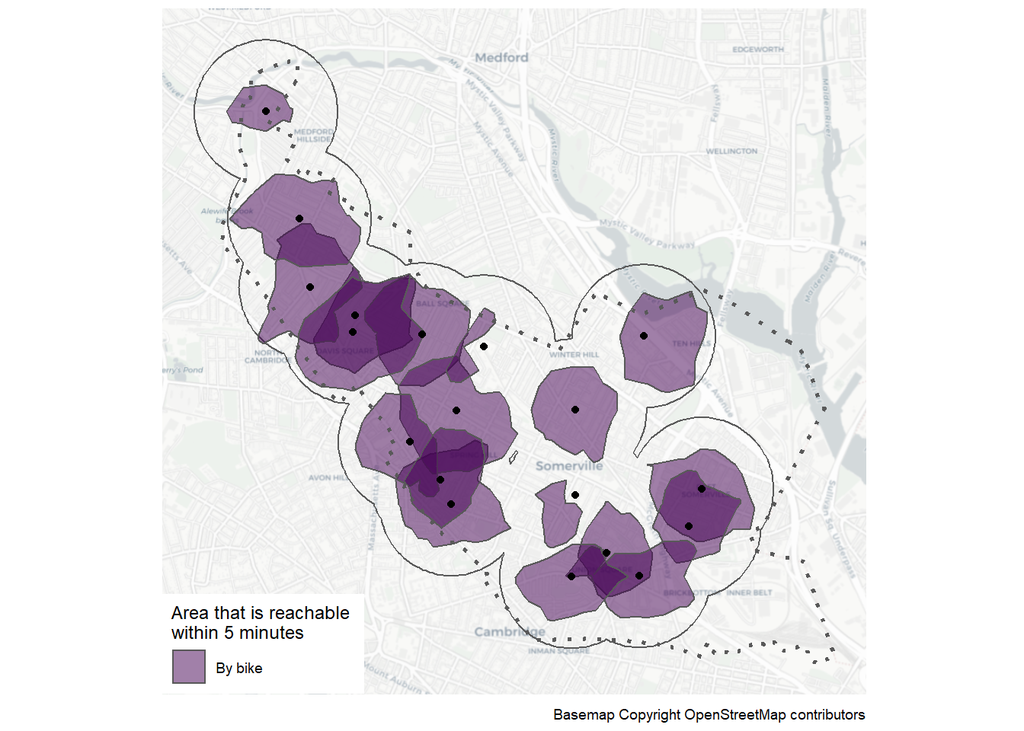

```r
# Mapping bike buffers

som_polling_ma <- som_polling %>%
  st_transform(crs = MA_state_plane)

bike_buffer <- st_buffer(som_polling_ma, dist = 600) %>%
  st_union()

ggplot(iso_5min_bike) +
  annotation_map_tile(zoomin = 0, type = "cartolight", progress = "none") +
  geom_sf(data = bike_buffer, fill = NA) +
  geom_sf(aes(fill = mode), alpha = 0.5) +
  geom_sf(data = som_polling) +
  coord_sf(xlim = c(left_side, right_side),
           ylim = c(bottom_side, top_side), expand = FALSE) +
  scale_fill_viridis_d(name = "Area that is reachable \nwithin 5 minutes",
                       labels = "By bike") +
  geom_sf(data = som_border, fill = NA, linetype = "dotted", size = 1) +
  theme_map() +
  labs(caption = "Basemap Copyright OpenStreetMap contributors")
```

The same figure for walking:

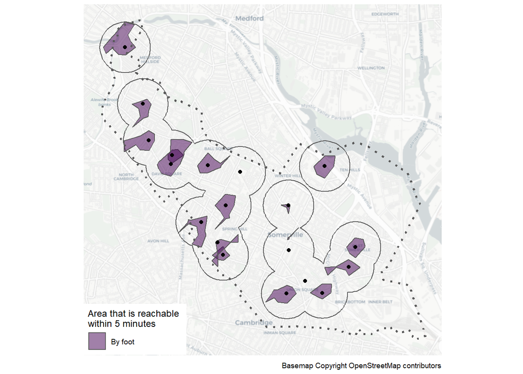

```r
#Mapping walking buffers

walk_buffer <- st_buffer(som_polling_ma, dist = 400) %>%
  st_union()

ggplot(iso_5min_walk) +
  annotation_map_tile(zoomin = 0, type = "cartolight", progress = "none") +
  geom_sf(data = walk_buffer, fill = NA) +
  geom_sf(aes(fill = mode), alpha = 0.5) +
  geom_sf(data = som_polling) +
  coord_sf(xlim = c(left_side, right_side),
           ylim = c(bottom_side, top_side), expand = FALSE) +
  scale_fill_viridis_d(name = "Area that is reachable \nwithin 5 minutes",
                       labels = "By foot") +
  geom_sf(data = som_border, fill = NA, linetype = "dotted", size = 1) +
  theme_map() +
  labs(caption = "Basemap Copyright OpenStreetMap contributors")
```

Finally, we can compare the area of these idealized buffers to the real-world walksheds and bikesheds. Interestingly, it seems as though biking does a better job of coverage than walking. Like the previous area chart, two polling place entries are not included becuase they did not generate walking isochrones.

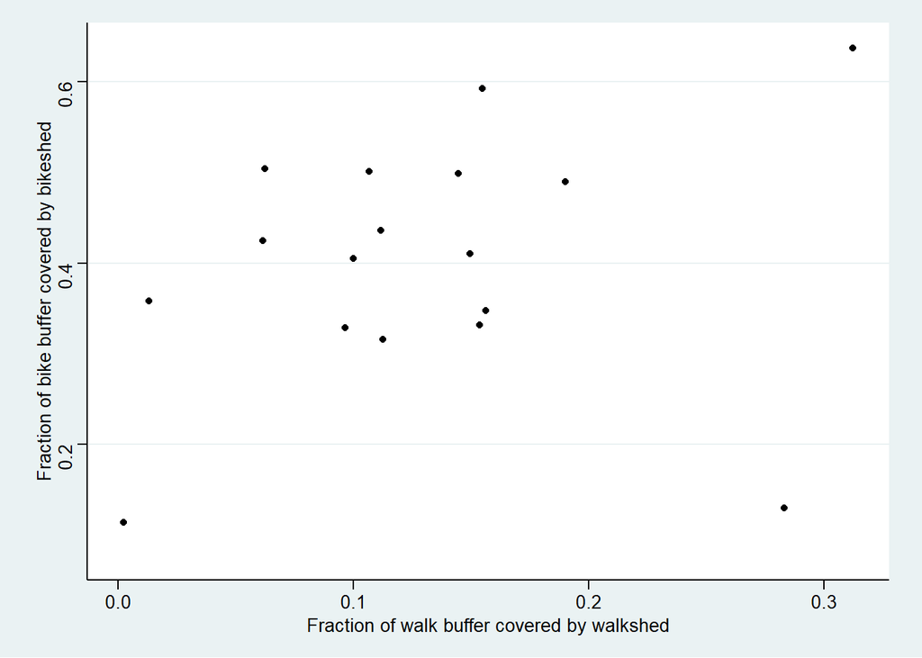

```r
# Compare isochrone coverage

bike_area <- pi*(600^2)

walk_area <- pi*(400^2)

ggplot(iso_areas,
       aes(x = (as.numeric(walk)/walk_area), y = (as.numeric(bike)/bike_area))) +
  geom_point() +
  scale_x_continuous(name = "Fraction of walk buffer covered by walkshed") +
  scale_y_continuous(name = "Fraction of bike buffer covered by bikeshed") +
  theme_stata()
```